# Predicting Car accident severity

Atheer Alkraida

September 5, 2020

## 1. Introduction

### 1.1 Background

Traffic accidents are considered as a significant cause of deaths, injuries, and property damage. It has been a main concern to the National Safety Council. Moreover, these accidents are affecting other individuals who are not mainly involved in the accident by delaying their trip and corrupting their plans. Having an understanding of what causes car accidents is the secret to avoid being involved in one. In other words, knowing how bad an accident can be based on certain identifiers can help individuals avoid suffering the consequences of being involved in them, by driving more carefully if came across these types of identifiers or even change their plans. Therefore, it became important to predict the severity of accidents based on their characteristics like if this accident will cause death fatalities or traffic delay, or any other bad impact of accidents.

### 1.2 Problem

Data that might contribute to determining the severity of each accident might include the characteristics that describe each accident like the type of collision, location, how many cars were involved in the accident, how many people were involved in the accident, weather condition, road condition, and some other characteristics that describe the causes of the collision. This project aims to predict the severity of accidents based on these data.

### 1.3 Interest

Obviously, drivers would be very interested in accurate prediction of accidents bad impacts so they can be proactive with regard to these undesired situations.

## 2. Data acquisition and cleaning

### 2.1 Data source

The dataset that will be used for building the predicting model is taken from the Seattle Police Department and it has all collisions that were recorded from 2004 to present. The dataset can be found in the following link: https://s3.us.cloud-object-storage.appdomain.cloud/cf-courses-data/CognitiveClass/DP0701EN/version-2/Data-Collisions.csv

### 2.2 Data cleaning

Data is downloaded from only one source. It has 38 columns and 194,673 records. The problems that I have identified within this dataset are as follow: First, I changed the data type for the accident date and the accident date/time from String to Date/Time. Second, there is an inconsistency in the values of the UNDERINFL column, this column tells whether or not a driver involved was under the influence of drugs or alcohol. The actual values have is either Yes or No, but we have 0 and 1 as well. Practically 0 represents No and 1 represent Yes, so I unified the representation for the data to the character representation. The third issue is the percentage of Null values within the dataset. Out of the current 38 columns, there are 18 features that contain Null values with percentages that vary from 0.009% to 97%. I dropped the columns that are unpredictable and the empty rows from the rest of the columns. The fourth issue that I faced, is that there is some inconsistency that I found in the relationship between the Accident time and the light condition, and the WEATHER and ROADCOND columns. I fixed these data inconsistencies and now my dataset is ready for analysis.

### 2.3 Feature selection

WEATHER

ADDRTYPE

COLLISIONTYPE

UNDERINFL

ROADCOND

LIGHTCOND

INCDTTM

PERSONCOUNT

VEHCOUNT

## 3. Exploratory Data Analysis

### 3.1 Calculation of target variable

The target variable which needs to be predicted is the Severity of the car accident. It has two possible values 1 or 2. Code number 1 refers to Property Damage Only Collision and code number 2 refers to Injury Collision.

### 3.2 Relationship between Severity of accidents and the Weather

It is well-known that individuals act more careless when they feel safer. And this is indeed reflected in our data. The number of accidents that happen in clear weather is way higher than when the weather is bad or risky. Following the clear weather in the highest number of accidents is rainy weather then overcast weather.

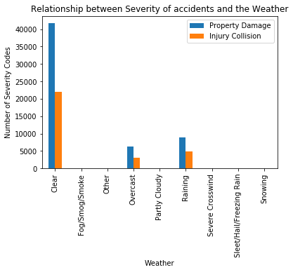

```python
CarAccidentsBySPD_DF.groupby(['WEATHER','SEVERITYCODE']).size().unstack().plot(kind='bar',stacked=False)
plt.title('Relationship between Severity of accidents and the Weather')
plt.xlabel('Weather')
plt.ylabel('Number of Severity Codes')
plt.legend(['Property Damage','Injury Collision'])
plt.show()
```

### 3.3 Relationship between Severity of the accident and the Address type

The highest number of no-injuries accidents happens at roads' blocks. This is quite normal because as we mentioned before that people pay more attention when they realize the level of danger a road has. The graph also shows that the number of injury collisions gets close to the property damage collisions when it comes to intersections.

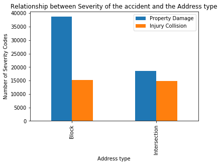

```python
CarAccidentsBySPD_DF.groupby(['ADDRTYPE','SEVERITYCODE']).size().unstack().plot(kind='bar',stacked=False)
plt.xlabel('Address type')
plt.title('Relationship between Severity of the accident and the Address type')
plt.ylabel('Number of Severity Codes')
plt.legend(['Property Damage','Injury Collision'])
plt.show()
```

### 3.4 Relationship between Severity of the accident and the Collision type

Next, we see that injuries happen more often when the collision is at the rear end of the car and at the car angles. But most property damage collisions happen to parked cars.

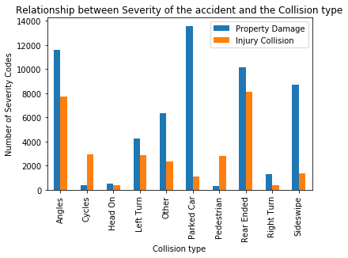

```python
CarAccidentsBySPD_DF.groupby(['COLLISIONTYPE','SEVERITYCODE']).size().unstack().plot(kind='bar',stacked=False)
plt.xlabel('Collision type')
plt.title('Relationship between Severity of the accident and the Collision type')
plt.ylabel('Number of Severity Codes')
plt.legend(['Property Damage','Injury Collision'])
plt.show()
```

### 3.5 Relationship between Severity of the accident and the influnce of drugs indicator

Surprisingly most accidents were done by people who are not under any drug or effection. This leads to the assumption that people's miss behavior might be the main cause for traffic accidents.

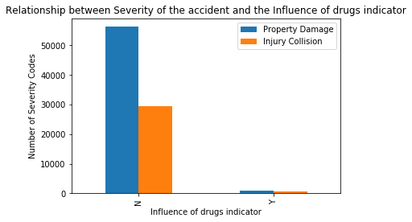

```python
CarAccidentsBySPD_DF.groupby(['UNDERINFL','SEVERITYCODE']).size().unstack().plot(kind='bar',stacked=False)
plt.xlabel('Influence of drugs indicator')
plt.title('Relationship between Severity of the accident and the Influence of drugs indicator')
plt.ylabel('Number of Severity Codes')
plt.legend(['Property Damage','Injury Collision'])
plt.show()
```

### 3.6 Relationship between Severity of the accident and the Road condition

Apparently, road condition doesn't affect the accidents and their appearances. Since the higher number is at the dry roads and there is only low number of accidents that happened on wet roads. Other conditions for roads are barely showing any accidents.

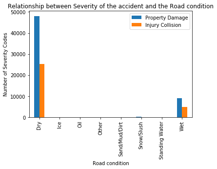

```python
CarAccidentsBySPD_DF.groupby(['ROADCOND','SEVERITYCODE']).size().unstack().plot(kind='bar',stacked=False)
plt.xlabel('Road condition')
plt.title('Relationship between Severity of the accident and the Road condition')
plt.ylabel('Number of Severity Codes')
plt.legend(['Property Damage','Injury Collision'])
plt.show()
```

### 3.7 Relationship between Severity of the accident and the Light condition

Just like the previous feature, light is not influencing the number of accidents. Having the highest number of accidents in the daylight means that accidents didn't happen because of the lack of lights on the road.

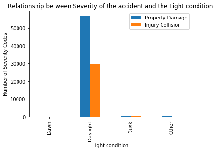

```python
CarAccidentsBySPD_DF.groupby(['LIGHTCOND','SEVERITYCODE']).size().unstack().plot(kind='bar',stacked=False)
plt.xlabel('Light condition')
plt.title('Relationship between Severity of the accident and the Light condition')
plt.ylabel('Number of Severity Codes')
plt.legend(['Property Damage','Injury Collision'])
plt.show()
```

### 3.8 Relationship between Severity of accident and the accident day

During the weekdays, accidents happen in a similar frequency, but the day that shows higher number of accidents is the last day of working days.

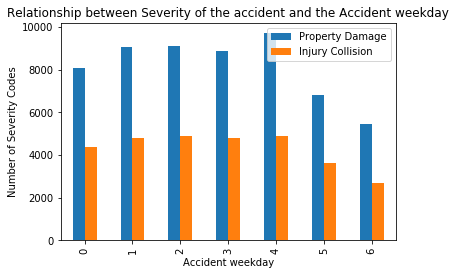

```python
CarAccidentsBySPD_DF['dayofweek'] = CarAccidentsBySPD_DF['INCDTTM'].dt.dayofweek
CarAccidentsBySPD_DF.groupby(['dayofweek','SEVERITYCODE']).size().unstack().plot(kind='bar',stacked=False)
plt.xlabel('Accident weekday')
plt.title('Relationship between Severity of the accident and the Accident weekday')
plt.ylabel('Number of Severity Codes')
plt.legend(['Property Damage','Injury Collision'])
plt.show()
```

It appears that the majority of accidents involves one-two cars only, and rarely three cars.

```
(0, 6)
```

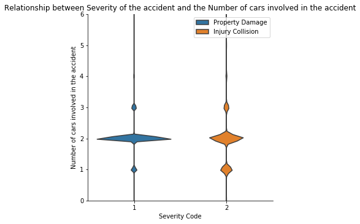

```python
sns.catplot(x="SEVERITYCODE", y="VEHCOUNT",kind="violin", inner=None, data=CarAccidentsBySPD_DF)
plt.xlabel('Severity Code')
plt.title('Relationship between Severity of the accident and the Number of cars involved in the accident')
plt.ylabel('Number of cars involved in the accident')
plt.legend(['Property Damage','Injury Collision'])
plt.ylim(0,6)
```

### 3.10 Relationship between Severity of the accident and the number of people involved in it

Most simple accidents that only cause property damage involves one to three people, but the accidents that cause injuries tend to have a higher number.

```
(0, 10)
```

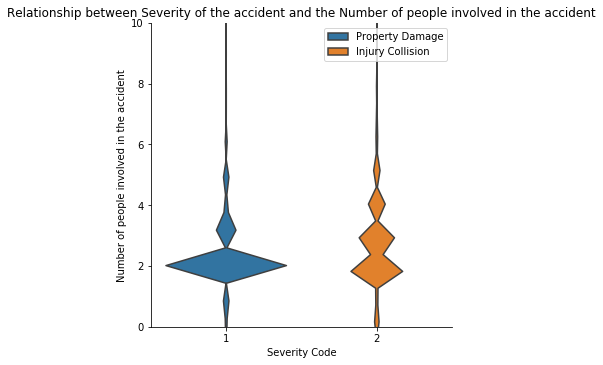

```python
sns.catplot(x="SEVERITYCODE", y="PERSONCOUNT",kind="violin", inner=None, data=CarAccidentsBySPD_DF)
plt.xlabel('Severity Code')
plt.title('Relationship between Severity of the accident and the Number of people involved in the accident')
plt.ylabel('Number of people involved in the accident')
plt.legend(['Property Damage','Injury Collision'])
plt.ylim(0,10)
```

## 4. Predictive Modeling

In this research we will use the classification model to predict to which category an accident might classified as based on the charactaristics that we have analyzed.

### 4.1 Classification models

| Testing mechanism | KKN | Logistic Regression | SVM | Decision_Tree |
| --- | --- | --- | --- | --- |
| Jaccard | 0.73 | 0.72 | 0.73 | 0.71 |
| F1-score | 0.70 | 0.68 | 0.68 | 0.65 |

## 5. Conclusions

In this study, I analyzed the relationship between the severity of car accidents and traffic accident characteristics. I identified address type, collision type, weather, and people count to be the most influencing features of the accident severity. I built a classification model to predict whether an accident will be an injury or property damage accident. These models can be very useful in helping individuals in a number of ways. For example, it could help identify which days to set plans for and when to drive more carefully, etc.

```python
from IPython.display import HTML

HTML('''<script>
code_show=true;
function code_toggle() {
 if (code_show){
 $('div.input').hide();
 } else {
 $('div.input').show();
 }
 code_show = !code_show
}
$( document ).ready(code_toggle);
</script>
<form action="javascript:code_toggle()"><input type="submit" value="Click here to toggle on/off the raw code."></form>''')
```